# Lab 014 — XGBoost from the formula up

## Follow the computation

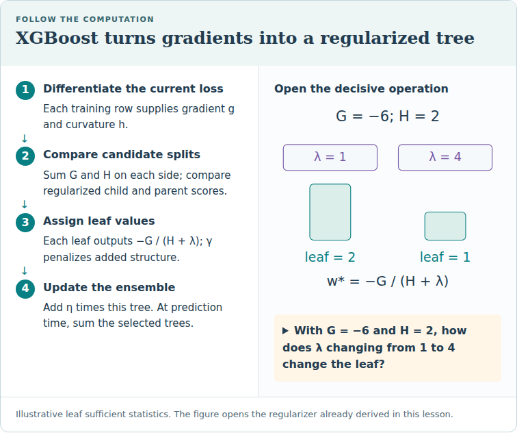

Illustrative leaf sufficient statistics. The figure opens the regularizer already derived in this lesson.

**Trace question:** With G = −6 and H = 2, how does λ changing from 1 to 4 change the leaf?

**Trace answer:** The leaf shrinks from 2 to 1: 6/(2+1) versus 6/(2+4).

**Lesson:** `lessons/0014-xgboost.html` · **Phase / Year:** Year 1 · Q2

**Paper:** Chen & Guestrin 2016, *XGBoost: A Scalable Tree Boosting System* (KDD) — §2, Eq 5–7.

**Dataset tiers:** C — synthetic squared-error toy (mechanism isolation) for Tasks 1–2; A — OpenML German credit (`credit_g`) via `relkit` for Task 3 (same harness as Labs 011–013).

**Skill you are practising:** implement XGBoost's **regularized leaf weight** and **structure-score split gain** by hand and check them against XGBoost's own leaf outputs; then fit and **tune** XGBoost with the shared CV harness and compare honestly to the L013 baseline.

**Exit criteria:** EXIT TICKET prints (1) your by-hand vs XGBoost leaf weights, (2) how λ shrinks weights and γ prunes a split, and (3) the credit_g CV PR-AUC for the L013 GBDT, default XGBoost, and tuned XGBoost.

### How this notebook works

- **PROVIDED** cells — complete boilerplate; just run.
- **TODO** cells — blanks (`____` / `# TODO`); you implement the skill.
- **CHECK** cells — immediate feedback; do not edit.
- Run top to bottom. When **EXIT TICKET** prints cleanly, paste it to your teacher or say *"lab done"*.

### Environment

One-time: `bash labs/setup-env.sh` from repo root → kernel **Relational Labs (.venv)**. This lab needs **xgboost** (already in `requirements-labs.txt`). No local install? Open from `notebooks.html` — **View** to read it rendered, or **Run on Binder**.

### Running on Google Colab?

Colab opens only this single file, so the course package (`relkit`) and the lab dependencies (xgboost, lightgbm, catboost, …) are **not** present by default. The cell below fixes that: on Colab it shallow-clones the course repo, installs `requirements-labs.txt`, and switches into `labs/` so `relkit` imports and the data cache resolve. **On a local venv or Binder it does nothing — just run it and continue.**

```python
# @colab-bootstrap — PROVIDED. Makes the lab self-sufficient on Google Colab; a no-op elsewhere.
import os, sys

if "google.colab" in sys.modules:
    if not os.path.isdir("/content/relational"):
        !git clone --depth 1 https://github.com/Avistian/relational.git /content/relational
    %pip install -q -r /content/relational/requirements-labs.txt
    os.chdir("/content/relational/labs")
    print("Colab ready — working dir:", os.getcwd())
else:
    print("Not on Colab — using the local environment as-is.")
```

## Concept recap — the two formulas that define XGBoost

Gradient boosting (Lesson 013) fits a tree to the residuals each round. XGBoost keeps that stagewise recipe but writes down a **regularized objective** and keeps the **second-order** term of the loss. For each row it uses the gradient $g_i$ and the hessian $h_i$; for a whole leaf it sums them: $G_j = \sum g_i$, $H_j = \sum h_i$.

The tree is penalized by $\Omega(f) = \gamma T + \tfrac{1}{2}\lambda \sum_j w_j^2$ (T = number of leaves). Minimizing the resulting quadratic gives two things:

- **Optimal leaf weight** (the value the leaf outputs): $$w_j^{*} = -\frac{G_j}{H_j + \lambda}$$
- **Structure score** of a node, whose per-leaf term measures leaf quality: $\dfrac{G_j^2}{H_j + \lambda}$. The gain of a split is then $$\text{Gain} = \tfrac{1}{2}\Big[\tfrac{G_L^2}{H_L+\lambda} + \tfrac{G_R^2}{H_R+\lambda} - \tfrac{(G_L+G_R)^2}{H_L+H_R+\lambda}\Big] - \gamma$$

**Callback (L011):** that bracket is *left child + right child − parent* — the same `ΔG = children − parent` shape as a Gini split, now in units of $G^2/(H+\lambda)$. The $-\gamma$ is a flat toll: if children don't beat the parent by more than $\gamma$, the gain is negative and the split is **pruned**.

**Toy micro-example (not this lab's answer):** a leaf holding rows with gradient sum $G=-6$, hessian sum $H=4$, and $\lambda=2$ outputs $w^{*} = -(-6)/(4+2) = +1.0$. Raise $\lambda$ to 10 and it shrinks to $6/14 \approx 0.43$ — that is L2 regularization pulling the leaf toward 0.

**Why it matters for the thesis:** a *tuned* XGBoost is *the* single-table baseline the relational thesis must beat fairly (Grinsztajn 2022). "We beat a default XGBoost" is not a result. Full derivation and the interactive λ/γ viz: Lesson 014 · Chen & Guestrin 2016 §2.

## Setup — PROVIDED

```python
# PROVIDED
import sys
from pathlib import Path
sys.path.insert(0, str(Path(".").resolve()))  # labs/ on the path so `relkit` imports

import warnings
warnings.filterwarnings("ignore")

import numpy as np
from sklearn.ensemble import GradientBoostingClassifier
from sklearn.model_selection import RandomizedSearchCV, StratifiedKFold
from sklearn.preprocessing import LabelEncoder
from xgboost import XGBClassifier, XGBRegressor

from relkit.data import load_tier_a
from relkit.metrics import cv_pr_auc

RS = 0
print("relkit + xgboost ok")
```

```
relkit + xgboost ok
```

## Task 1 — the leaf weight & split gain, by hand — TODO (crucial fragment)

**Goal:** implement XGBoost's three §2 formulas — node score, regularized leaf weight, and split gain — and reproduce XGBoost's *own* leaf outputs exactly.

**Why it matters:** these formulas *are* XGBoost. Once you can compute the leaf value XGBoost prints, the model stops being a black box: every knob (`reg_lambda`, `gamma`) is just a term you wrote here.

**You implement (3 one-line returns):**

1. `node_score(G, H, lam)` → $G^2/(H+\lambda)$
2. `reg_leaf_weight(G, H, lam)` → $-G/(H+\lambda)$
3. `split_gain(GL, HL, GR, HR, lam, gamma)` → $\tfrac{1}{2}[\text{score}(L)+\text{score}(R)-\text{score(parent)}]-\gamma$

**Hint boundary:** the parent's stats are the sums $G_L+G_R$ and $H_L+H_R$; reuse `node_score` inside `split_gain`. Do **not** read the leaf value off XGBoost — compute it, then compare.

```python
# PROVIDED — a squared-error toy so g = pred - y and h = 1 (base_score 0.5).
# We fit a single XGBoost stump, read its split, and gather leaf gradient/hessian sums.
rng = np.random.RandomState(0)
Xr = rng.uniform(0, 1, size=(40, 1))
yr = (Xr[:, 0] > 0.5).astype(float) * 4.0 + rng.normal(0, 0.2, 40)

LAMBDA = 3.0
stump = XGBRegressor(
    n_estimators=1, max_depth=1, learning_rate=1.0,
    reg_lambda=LAMBDA, reg_alpha=0.0, gamma=0.0, base_score=0.5,
    objective="reg:squarederror", random_state=RS,
).fit(Xr, yr)

g = np.full(len(yr), 0.5) - yr      # gradient of ½(pred - y)^2 at pred = 0.5
h = np.ones_like(yr)                # hessian = 1

df = stump.get_booster().trees_to_dataframe()
thr = float(df[df["Feature"] != "Leaf"].iloc[0]["Split"])
left = Xr[:, 0] < thr
GL, HL = g[left].sum(), h[left].sum()
GR, HR = g[~left].sum(), h[~left].sum()
xgb_leaf_vals = df[df["Feature"] == "Leaf"].sort_values("Node")["Gain"].to_numpy()
print(f"split threshold = {thr:.4f}   GL,HL = {GL:.2f},{HL:.0f}   GR,HR = {GR:.2f},{HR:.0f}")
```

```
split threshold = 0.5218   GL,HL = 7.68,13   GR,HR = -92.84,27
```

```python
# TODO — implement the three XGBoost formulas (Chen & Guestrin 2016, §2)
def node_score(G, H, lam):
    return (G**2) / (H+lam)                    # G^2 / (H + lam)

def reg_leaf_weight(G, H, lam):
    return -G / (H+lam)                      # -G / (H + lam)

def split_gain(GL, HL, GR, HR, lam, gamma):
    children = node_score(GL, HL, lam) + node_score(GR, HR, lam)                  # node_score(L) + node_score(R)
    parent = (GL + GR)**2/(lam + HL + HR)                    # node_score of the combined parent
    return 0.5 * (children - parent) - gamma

wL = reg_leaf_weight(GL, HL, LAMBDA)
wR = reg_leaf_weight(GR, HR, LAMBDA)
print(f"by-hand leaf weights  L/R = {wL:+.4f} / {wR:+.4f}")
print(f"XGBoost leaf weights      = {np.sort(xgb_leaf_vals)}")
```

```
by-hand leaf weights  L/R = -0.4798 / +3.0947
XGBoost leaf weights      = [-0.47984645  3.09472299]
```

```python
# CHECK — do not edit
assert np.isclose(node_score(4.0, 20.0, 0.0), 16.0 / 20.0), "node_score should be G^2/(H+lam)."
assert np.allclose(np.sort([wL, wR]), np.sort(xgb_leaf_vals), atol=1e-3), \
    "Your leaf weights should match XGBoost's own leaf outputs (they are the same formula)."
print("Task 1 ok — your formula reproduces XGBoost's leaf weights exactly.")
```

```
Task 1 ok — your formula reproduces XGBoost's leaf weights exactly.
```

## Task 2 — feel the regularizers λ and γ — TODO

**Goal:** show numerically that (a) raising **λ** shrinks a leaf weight toward 0, and (b) raising **γ** past the raw gain flips a split from KEEP to PRUNE.

**Why it matters:** these are the two knobs that make XGBoost hard to overfit on small, noisy data — exactly the regime where L013 showed a Random Forest can tie a booster. Tuning them is most of the game.

**You implement:** two list comprehensions that reuse your Task-1 functions — `weights_by_lambda` (leaf weight of the LEFT leaf at each λ) and `net_gains` (split gain at each γ toll, λ fixed at 1.0).

```python
# TODO — sweep λ (shrinkage) and γ (pruning toll)
lam_grid = [0.0, 1.0, 3.0, 10.0]
weights_by_lambda = [reg_leaf_weight(GL, HL, l) for l in lam_grid]        # reg_leaf_weight of LEFT leaf at each λ

raw_gain = split_gain(GL, HL, GR, HR, lam=1.0, gamma=0.0)
gammas = [0.0, raw_gain * 0.5, raw_gain * 1.5]
net_gains = [split_gain(GL, HL, GR, HR, 1, gm) for gm in gammas]                 # split_gain at each γ (λ=1.0)

for l, w in zip(lam_grid, weights_by_lambda):
    print(f"  λ={l:5.1f}  left-leaf w* = {w:+.4f}")
print(f"raw gain (γ=0) = {raw_gain:.3f}")
for gm, ng in zip(gammas, net_gains):
    print(f"  γ={gm:6.3f}  net gain = {ng:+.3f}  ->  {'KEEP' if ng > 0 else 'PRUNE'}")
```

```
  λ=  0.0  left-leaf w* = -0.5906
  λ=  1.0  left-leaf w* = -0.5484
  λ=  3.0  left-leaf w* = -0.4798
  λ= 10.0  left-leaf w* = -0.3338
raw gain (γ=0) = 67.576
  γ= 0.000  net gain = +67.576  ->  KEEP
  γ=33.788  net gain = +33.788  ->  KEEP
  γ=101.364  net gain = -33.788  ->  PRUNE
```

```python
# CHECK — do not edit
assert abs(weights_by_lambda[0]) > abs(weights_by_lambda[-1]), "λ should shrink |w| toward 0."
assert net_gains[0] > 0 and net_gains[-1] < 0, \
    "γ below the raw gain keeps the split; γ above it should prune (net gain < 0)."
print("Task 2 ok — λ shrinks weights; γ past the raw gain prunes the split.")
```

```
Task 2 ok — λ shrinks weights; γ past the raw gain prunes the split.
```